# Risk Factor Analysis

## Outcome Variable

**Outcome Variable:** sstunted

## Predictor Variables

**Intervention Variable:** single

**Adjustment Set:**

unadjusted

## Stratifying Variables

The analysis was stratified on these variable(s):

- agecat
- studyid

The following strata were considered:

- agecat: 12 months, studyid: ki0047075b-MAL-ED
- agecat: 12 months, studyid: ki1066203-TanzaniaChild2
- agecat: 12 months, studyid: ki1112895-Guatemala BSC
- agecat: 12 months, studyid: ki1126311-ZVITAMBO
- agecat: 12 months, studyid: ki1135781-COHORTS
- agecat: 18 months, studyid: ki0047075b-MAL-ED
- agecat: 18 months, studyid: ki1066203-TanzaniaChild2
- agecat: 18 months, studyid: ki1126311-ZVITAMBO
- agecat: 18 months, studyid: ki1135781-COHORTS
- agecat: 24 months, studyid: ki0047075b-MAL-ED
- agecat: 24 months, studyid: ki1066203-TanzaniaChild2
- agecat: 24 months, studyid: ki1126311-ZVITAMBO
- agecat: 24 months, studyid: ki1135781-COHORTS
- agecat: 3 months, studyid: ki0047075b-MAL-ED
- agecat: 3 months, studyid: ki1066203-TanzaniaChild2
- agecat: 3 months, studyid: ki1112895-Guatemala BSC
- agecat: 3 months, studyid: ki1126311-ZVITAMBO
- agecat: 3 months, studyid: ki1135781-COHORTS
- agecat: 6 months, studyid: ki0047075b-MAL-ED
- agecat: 6 months, studyid: ki1066203-TanzaniaChild2
- agecat: 6 months, studyid: ki1112895-Guatemala BSC
- agecat: 6 months, studyid: ki1126311-ZVITAMBO
- agecat: 6 months, studyid: ki1135781-COHORTS
- agecat: 9 months, studyid: ki0047075b-MAL-ED
- agecat: 9 months, studyid: ki1066203-TanzaniaChild2
- agecat: 9 months, studyid: ki1112895-Guatemala BSC
- agecat: 9 months, studyid: ki1126311-ZVITAMBO
- agecat: 9 months, studyid: ki1135781-COHORTS
- agecat: Birth, studyid: ki0047075b-MAL-ED
- agecat: Birth, studyid: ki1126311-ZVITAMBO
- agecat: Birth, studyid: ki1135781-COHORTS

### Dropped Strata

Some strata were dropped due to rare outcomes:

- agecat: Birth, studyid: ki1135781-COHORTS
- agecat: 3 months, studyid: ki1066203-TanzaniaChild2
- agecat: 3 months, studyid: ki1112895-Guatemala BSC
- agecat: 6 months, studyid: ki1066203-TanzaniaChild2
- agecat: 6 months, studyid: ki1112895-Guatemala BSC
- agecat: 9 months, studyid: ki1066203-TanzaniaChild2
- agecat: 9 months, studyid: ki1112895-Guatemala BSC
- agecat: 12 months, studyid: ki1066203-TanzaniaChild2
- agecat: 12 months, studyid: ki1112895-Guatemala BSC
- agecat: 18 months, studyid: ki1066203-TanzaniaChild2
- agecat: 24 months, studyid: ki1066203-TanzaniaChild2
- agecat: 24 months, studyid: ki1126311-ZVITAMBO

## Methods Detail

We’re interested in the causal parameters $E[Y_a]$ for all values of $a \in \mathcal{A}$. These parameters represent the mean outcome if, possibly contrary to fact, we intervened to set all units to have $A=a$. Under the randomization and positivity assumptions, these are identified by the statistical parameters $\psi_a=E_W[E_{Y|A,W}(Y|A=a,W)]$. In addition, we’re interested in the mean of $Y$, $E[Y]$ under no intervention (the observed mean). We will estimate these parameters by using SuperLearner to fit the relevant likelihood factors – $E_{Y|A,W}(Y|A=a,W)$ and $p(A=a|W)$, and then updating our likelihood fit using a joint TMLE.

For unadjusted analyses ($W=\{\}$), initial likelihoods were estimated using Lrnr_glm to estimate the simple $E(Y|A)$ and Lrnr_mean to estimate $p(A)$. For adjusted analyses, a small library containing Lrnr_glmnet, Lrnr_xgboost, and Lrnr_mean was used.

Having estimated these parameters, we will then use the delta method to estimate relative risks and attributable risks relative to a prespecified baseline level of $A$.

# Results Detail

## Results Plots

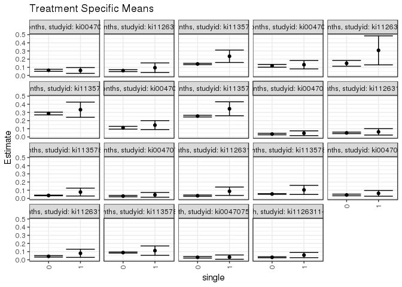

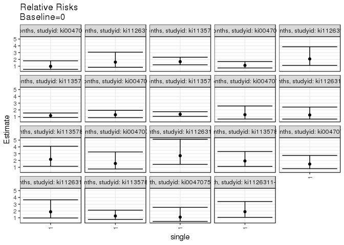

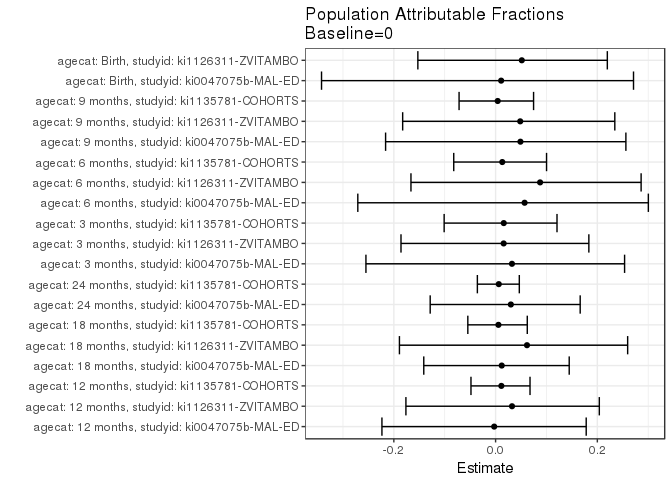

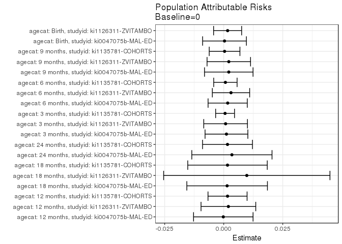

## Data Summary

| agecat | studyid | A | n | nA | nAY0 | nAY1 |
| --- | --- | --- | --- | --- | --- | --- |
| Birth | ki0047075b-MAL-ED | 0 | 1498 | 1317 | 1277 | 40 |
| Birth | ki0047075b-MAL-ED | 1 | 1498 | 181 | 175 | 6 |
| Birth | ki1066203-TanzaniaChild2 | 0 | 0 | 0 | 0 | 0 |
| Birth | ki1066203-TanzaniaChild2 | 1 | 0 | 0 | 0 | 0 |
| Birth | ki1112895-Guatemala BSC | 0 | 0 | 0 | 0 | 0 |
| Birth | ki1112895-Guatemala BSC | 1 | 0 | 0 | 0 | 0 |
| Birth | ki1126311-ZVITAMBO | 0 | 3427 | 3219 | 3121 | 98 |
| Birth | ki1126311-ZVITAMBO | 1 | 3427 | 208 | 196 | 12 |
| Birth | ki1135781-COHORTS | 0 | 8151 | 8041 | 7855 | 186 |
| Birth | ki1135781-COHORTS | 1 | 8151 | 110 | 108 | 2 |
| 3 months | ki0047075b-MAL-ED | 0 | 1776 | 1577 | 1522 | 55 |
| 3 months | ki0047075b-MAL-ED | 1 | 1776 | 199 | 190 | 9 |
| 3 months | ki1066203-TanzaniaChild2 | 0 | 569 | 511 | 502 | 9 |
| 3 months | ki1066203-TanzaniaChild2 | 1 | 569 | 58 | 57 | 1 |
| 3 months | ki1112895-Guatemala BSC | 0 | 4 | 4 | 2 | 2 |
| 3 months | ki1112895-Guatemala BSC | 1 | 4 | 0 | 0 | 0 |
| 3 months | ki1126311-ZVITAMBO | 0 | 2262 | 2117 | 2012 | 105 |
| 3 months | ki1126311-ZVITAMBO | 1 | 2262 | 145 | 136 | 9 |
| 3 months | ki1135781-COHORTS | 0 | 8360 | 8243 | 7950 | 293 |
| 3 months | ki1135781-COHORTS | 1 | 8360 | 117 | 108 | 9 |
| 6 months | ki0047075b-MAL-ED | 0 | 1694 | 1509 | 1467 | 42 |
| 6 months | ki0047075b-MAL-ED | 1 | 1694 | 185 | 177 | 8 |
| 6 months | ki1066203-TanzaniaChild2 | 0 | 499 | 451 | 446 | 5 |
| 6 months | ki1066203-TanzaniaChild2 | 1 | 499 | 48 | 46 | 2 |
| 6 months | ki1112895-Guatemala BSC | 0 | 90 | 84 | 77 | 7 |
| 6 months | ki1112895-Guatemala BSC | 1 | 90 | 6 | 5 | 1 |
| 6 months | ki1126311-ZVITAMBO | 0 | 2041 | 1926 | 1864 | 62 |
| 6 months | ki1126311-ZVITAMBO | 1 | 2041 | 115 | 105 | 10 |
| 6 months | ki1135781-COHORTS | 0 | 8075 | 7959 | 7532 | 427 |
| 6 months | ki1135781-COHORTS | 1 | 8075 | 116 | 104 | 12 |
| 9 months | ki0047075b-MAL-ED | 0 | 1638 | 1459 | 1398 | 61 |
| 9 months | ki0047075b-MAL-ED | 1 | 1638 | 179 | 168 | 11 |
| 9 months | ki1066203-TanzaniaChild2 | 0 | 432 | 392 | 385 | 7 |
| 9 months | ki1066203-TanzaniaChild2 | 1 | 432 | 40 | 40 | 0 |
| 9 months | ki1112895-Guatemala BSC | 0 | 60 | 57 | 49 | 8 |
| 9 months | ki1112895-Guatemala BSC | 1 | 60 | 3 | 2 | 1 |
| 9 months | ki1126311-ZVITAMBO | 0 | 1954 | 1841 | 1763 | 78 |
| 9 months | ki1126311-ZVITAMBO | 1 | 1954 | 113 | 104 | 9 |
| 9 months | ki1135781-COHORTS | 0 | 7451 | 7335 | 6686 | 649 |
| 9 months | ki1135781-COHORTS | 1 | 7451 | 116 | 103 | 13 |
| 12 months | ki0047075b-MAL-ED | 0 | 1614 | 1436 | 1345 | 91 |
| 12 months | ki0047075b-MAL-ED | 1 | 1614 | 178 | 167 | 11 |
| 12 months | ki1066203-TanzaniaChild2 | 0 | 356 | 318 | 312 | 6 |
| 12 months | ki1066203-TanzaniaChild2 | 1 | 356 | 38 | 37 | 1 |
| 12 months | ki1112895-Guatemala BSC | 0 | 53 | 50 | 40 | 10 |
| 12 months | ki1112895-Guatemala BSC | 1 | 53 | 3 | 2 | 1 |
| 12 months | ki1126311-ZVITAMBO | 0 | 1695 | 1600 | 1505 | 95 |
| 12 months | ki1126311-ZVITAMBO | 1 | 1695 | 95 | 86 | 9 |
| 12 months | ki1135781-COHORTS | 0 | 6924 | 6805 | 5845 | 960 |
| 12 months | ki1135781-COHORTS | 1 | 6924 | 119 | 91 | 28 |
| 18 months | ki0047075b-MAL-ED | 0 | 1544 | 1377 | 1214 | 163 |
| 18 months | ki0047075b-MAL-ED | 1 | 1544 | 167 | 145 | 22 |
| 18 months | ki1066203-TanzaniaChild2 | 0 | 257 | 232 | 220 | 12 |
| 18 months | ki1066203-TanzaniaChild2 | 1 | 257 | 25 | 22 | 3 |
| 18 months | ki1112895-Guatemala BSC | 0 | 0 | 0 | 0 | 0 |
| 18 months | ki1112895-Guatemala BSC | 1 | 0 | 0 | 0 | 0 |
| 18 months | ki1126311-ZVITAMBO | 0 | 423 | 397 | 338 | 59 |
| 18 months | ki1126311-ZVITAMBO | 1 | 423 | 26 | 18 | 8 |
| 18 months | ki1135781-COHORTS | 0 | 2872 | 2773 | 1978 | 795 |
| 18 months | ki1135781-COHORTS | 1 | 2872 | 99 | 66 | 33 |
| 24 months | ki0047075b-MAL-ED | 0 | 1487 | 1328 | 1179 | 149 |
| 24 months | ki0047075b-MAL-ED | 1 | 1487 | 159 | 136 | 23 |
| 24 months | ki1066203-TanzaniaChild2 | 0 | 2 | 2 | 2 | 0 |
| 24 months | ki1066203-TanzaniaChild2 | 1 | 2 | 0 | 0 | 0 |
| 24 months | ki1112895-Guatemala BSC | 0 | 0 | 0 | 0 | 0 |
| 24 months | ki1112895-Guatemala BSC | 1 | 0 | 0 | 0 | 0 |
| 24 months | ki1126311-ZVITAMBO | 0 | 116 | 103 | 85 | 18 |
| 24 months | ki1126311-ZVITAMBO | 1 | 116 | 13 | 9 | 4 |
| 24 months | ki1135781-COHORTS | 0 | 6658 | 6539 | 4873 | 1666 |
| 24 months | ki1135781-COHORTS | 1 | 6658 | 119 | 78 | 41 |

## Results Table

### Parameter: TSM

| agecat | studyid | intervention_level | baseline_level | estimate | ci_lower | ci_upper |
| --- | --- | --- | --- | --- | --- | --- |
| Birth | ki0047075b-MAL-ED | 0 | NA | 0.0303721 | 0.0211008 | 0.0396433 |
| Birth | ki0047075b-MAL-ED | 1 | NA | 0.0331492 | 0.0070594 | 0.0592389 |
| Birth | ki1126311-ZVITAMBO | 0 | NA | 0.0304442 | 0.0245083 | 0.0363802 |
| Birth | ki1126311-ZVITAMBO | 1 | NA | 0.0576923 | 0.0260014 | 0.0893832 |
| 3 months | ki0047075b-MAL-ED | 0 | NA | 0.0348763 | 0.0258188 | 0.0439339 |
| 3 months | ki0047075b-MAL-ED | 1 | NA | 0.0452261 | 0.0163467 | 0.0741056 |
| 3 months | ki1126311-ZVITAMBO | 0 | NA | 0.0495985 | 0.0403479 | 0.0588491 |
| 3 months | ki1126311-ZVITAMBO | 1 | NA | 0.0620690 | 0.0227879 | 0.1013500 |
| 3 months | ki1135781-COHORTS | 0 | NA | 0.0355453 | 0.0315480 | 0.0395426 |
| 3 months | ki1135781-COHORTS | 1 | NA | 0.0769231 | 0.0286363 | 0.1252099 |
| 6 months | ki0047075b-MAL-ED | 0 | NA | 0.0278330 | 0.0195310 | 0.0361350 |
| 6 months | ki0047075b-MAL-ED | 1 | NA | 0.0432432 | 0.0139242 | 0.0725623 |
| 6 months | ki1126311-ZVITAMBO | 0 | NA | 0.0321911 | 0.0243063 | 0.0400758 |
| 6 months | ki1126311-ZVITAMBO | 1 | NA | 0.0869565 | 0.0354452 | 0.1384678 |
| 6 months | ki1135781-COHORTS | 0 | NA | 0.0536500 | 0.0486994 | 0.0586005 |
| 6 months | ki1135781-COHORTS | 1 | NA | 0.1034483 | 0.0480246 | 0.1588719 |
| 9 months | ki0047075b-MAL-ED | 0 | NA | 0.0418095 | 0.0315360 | 0.0520829 |
| 9 months | ki0047075b-MAL-ED | 1 | NA | 0.0614525 | 0.0262599 | 0.0966452 |
| 9 months | ki1126311-ZVITAMBO | 0 | NA | 0.0423683 | 0.0331648 | 0.0515718 |
| 9 months | ki1126311-ZVITAMBO | 1 | NA | 0.0796460 | 0.0297140 | 0.1295781 |
| 9 months | ki1135781-COHORTS | 0 | NA | 0.0884799 | 0.0819804 | 0.0949794 |
| 9 months | ki1135781-COHORTS | 1 | NA | 0.1120690 | 0.0546599 | 0.1694780 |
| 12 months | ki0047075b-MAL-ED | 0 | NA | 0.0633705 | 0.0507658 | 0.0759752 |
| 12 months | ki0047075b-MAL-ED | 1 | NA | 0.0617978 | 0.0264137 | 0.0971818 |
| 12 months | ki1126311-ZVITAMBO | 0 | NA | 0.0593750 | 0.0477919 | 0.0709581 |
| 12 months | ki1126311-ZVITAMBO | 1 | NA | 0.0947368 | 0.0358306 | 0.1536431 |
| 12 months | ki1135781-COHORTS | 0 | NA | 0.1410727 | 0.1328016 | 0.1493439 |
| 12 months | ki1135781-COHORTS | 1 | NA | 0.2352941 | 0.1590759 | 0.3115123 |
| 18 months | ki0047075b-MAL-ED | 0 | NA | 0.1183733 | 0.1013049 | 0.1354416 |
| 18 months | ki0047075b-MAL-ED | 1 | NA | 0.1317365 | 0.0804257 | 0.1830474 |
| 18 months | ki1126311-ZVITAMBO | 0 | NA | 0.1486146 | 0.1135830 | 0.1836463 |
| 18 months | ki1126311-ZVITAMBO | 1 | NA | 0.3076923 | 0.1300758 | 0.4853088 |
| 18 months | ki1135781-COHORTS | 0 | NA | 0.2866931 | 0.2698588 | 0.3035274 |
| 18 months | ki1135781-COHORTS | 1 | NA | 0.3333333 | 0.2404581 | 0.4262086 |
| 24 months | ki0047075b-MAL-ED | 0 | NA | 0.1121988 | 0.0952184 | 0.1291792 |
| 24 months | ki0047075b-MAL-ED | 1 | NA | 0.1446541 | 0.0899611 | 0.1993471 |
| 24 months | ki1135781-COHORTS | 0 | NA | 0.2547790 | 0.2442169 | 0.2653411 |
| 24 months | ki1135781-COHORTS | 1 | NA | 0.3445378 | 0.2591493 | 0.4299263 |

### Parameter: E(Y)

| agecat | studyid | intervention_level | baseline_level | estimate | ci_lower | ci_upper |
| --- | --- | --- | --- | --- | --- | --- |
| Birth | ki0047075b-MAL-ED | NA | NA | 0.0307076 | 0.0306618 | 0.0307535 |
| Birth | ki1126311-ZVITAMBO | NA | NA | 0.0320980 | 0.0318802 | 0.0323159 |
| 3 months | ki0047075b-MAL-ED | NA | NA | 0.0360360 | 0.0358842 | 0.0361879 |
| 3 months | ki1126311-ZVITAMBO | NA | NA | 0.0503979 | 0.0502720 | 0.0505238 |
| 3 months | ki1135781-COHORTS | NA | NA | 0.0361244 | 0.0360202 | 0.0362286 |
| 6 months | ki0047075b-MAL-ED | NA | NA | 0.0295159 | 0.0292870 | 0.0297449 |
| 6 months | ki1126311-ZVITAMBO | NA | NA | 0.0352768 | 0.0347288 | 0.0358248 |
| 6 months | ki1135781-COHORTS | NA | NA | 0.0543653 | 0.0542361 | 0.0544946 |
| 9 months | ki0047075b-MAL-ED | NA | NA | 0.0439560 | 0.0436592 | 0.0442529 |
| 9 months | ki1126311-ZVITAMBO | NA | NA | 0.0445241 | 0.0441381 | 0.0449100 |
| 9 months | ki1135781-COHORTS | NA | NA | 0.0888471 | 0.0887808 | 0.0889134 |
| 12 months | ki0047075b-MAL-ED | NA | NA | 0.0631970 | 0.0631730 | 0.0632211 |
| 12 months | ki1126311-ZVITAMBO | NA | NA | 0.0613569 | 0.0609696 | 0.0617443 |
| 12 months | ki1135781-COHORTS | NA | NA | 0.1426921 | 0.1424036 | 0.1429805 |
| 18 months | ki0047075b-MAL-ED | NA | NA | 0.1198187 | 0.1196116 | 0.1200257 |
| 18 months | ki1126311-ZVITAMBO | NA | NA | 0.1583924 | 0.1547471 | 0.1620378 |
| 18 months | ki1135781-COHORTS | NA | NA | 0.2883008 | 0.2879896 | 0.2886121 |
| 24 months | ki0047075b-MAL-ED | NA | NA | 0.1156691 | 0.1151592 | 0.1161791 |
| 24 months | ki1135781-COHORTS | NA | NA | 0.2563833 | 0.2560976 | 0.2566690 |

### Parameter: RR

| agecat | studyid | intervention_level | baseline_level | estimate | ci_lower | ci_upper |
| --- | --- | --- | --- | --- | --- | --- |
| Birth | ki0047075b-MAL-ED | 1 | 0 | 1.0914365 | 0.4692261 | 2.538720 |
| Birth | ki1126311-ZVITAMBO | 1 | 0 | 1.8950157 | 1.0579574 | 3.394357 |
| 3 months | ki0047075b-MAL-ED | 1 | 0 | 1.2967565 | 0.6508460 | 2.583680 |
| 3 months | ki1126311-ZVITAMBO | 1 | 0 | 1.2514286 | 0.6469500 | 2.420702 |
| 3 months | ki1135781-COHORTS | 1 | 0 | 2.1640851 | 1.1437082 | 4.094807 |
| 6 months | ki0047075b-MAL-ED | 1 | 0 | 1.5536680 | 0.7407465 | 3.258718 |
| 6 months | ki1126311-ZVITAMBO | 1 | 0 | 2.7012623 | 1.4229018 | 5.128125 |
| 6 months | ki1135781-COHORTS | 1 | 0 | 1.9282080 | 1.1195654 | 3.320919 |
| 9 months | ki0047075b-MAL-ED | 1 | 0 | 1.4698232 | 0.7881802 | 2.740973 |
| 9 months | ki1126311-ZVITAMBO | 1 | 0 | 1.8798502 | 0.9682161 | 3.649843 |
| 9 months | ki1135781-COHORTS | 1 | 0 | 1.2666038 | 0.7549026 | 2.125155 |
| 12 months | ki0047075b-MAL-ED | 1 | 0 | 0.9751821 | 0.5319140 | 1.787846 |
| 12 months | ki1126311-ZVITAMBO | 1 | 0 | 1.5955679 | 0.8315666 | 3.061495 |
| 12 months | ki1135781-COHORTS | 1 | 0 | 1.6678922 | 1.2000582 | 2.318108 |
| 18 months | ki0047075b-MAL-ED | 1 | 0 | 1.1128908 | 0.7346448 | 1.685884 |
| 18 months | ki1126311-ZVITAMBO | 1 | 0 | 2.0704042 | 1.1098407 | 3.862332 |
| 18 months | ki1135781-COHORTS | 1 | 0 | 1.1626834 | 0.8745768 | 1.545699 |
| 24 months | ki0047075b-MAL-ED | 1 | 0 | 1.2892660 | 0.8579697 | 1.937372 |
| 24 months | ki1135781-COHORTS | 1 | 0 | 1.3523006 | 1.0518274 | 1.738609 |

### Parameter: PAR

| agecat | studyid | intervention_level | baseline_level | estimate | ci_lower | ci_upper |
| --- | --- | --- | --- | --- | --- | --- |
| Birth | ki0047075b-MAL-ED | 0 | NA | 0.0003356 | -0.0089358 | 0.0096069 |
| Birth | ki1126311-ZVITAMBO | 0 | NA | 0.0016538 | -0.0042861 | 0.0075937 |
| 3 months | ki0047075b-MAL-ED | 0 | NA | 0.0011597 | -0.0078992 | 0.0102185 |
| 3 months | ki1126311-ZVITAMBO | 0 | NA | 0.0007994 | -0.0084521 | 0.0100509 |
| 3 months | ki1135781-COHORTS | 0 | NA | 0.0005791 | -0.0034195 | 0.0045777 |
| 6 months | ki0047075b-MAL-ED | 0 | NA | 0.0016829 | -0.0066222 | 0.0099881 |
| 6 months | ki1126311-ZVITAMBO | 0 | NA | 0.0030858 | -0.0048180 | 0.0109895 |
| 6 months | ki1135781-COHORTS | 0 | NA | 0.0007154 | -0.0042369 | 0.0056676 |
| 9 months | ki0047075b-MAL-ED | 0 | NA | 0.0021466 | -0.0081312 | 0.0124243 |
| 9 months | ki1126311-ZVITAMBO | 0 | NA | 0.0021558 | -0.0070558 | 0.0113673 |
| 9 months | ki1135781-COHORTS | 0 | NA | 0.0003672 | -0.0061326 | 0.0068671 |
| 12 months | ki0047075b-MAL-ED | 0 | NA | -0.0001734 | -0.0127782 | 0.0124313 |
| 12 months | ki1126311-ZVITAMBO | 0 | NA | 0.0019819 | -0.0096077 | 0.0135715 |
| 12 months | ki1135781-COHORTS | 0 | NA | 0.0016193 | -0.0066568 | 0.0098955 |
| 18 months | ki0047075b-MAL-ED | 0 | NA | 0.0014454 | -0.0156242 | 0.0185150 |
| 18 months | ki1126311-ZVITAMBO | 0 | NA | 0.0097778 | -0.0254430 | 0.0449986 |
| 18 months | ki1135781-COHORTS | 0 | NA | 0.0016077 | -0.0152295 | 0.0184449 |
| 24 months | ki0047075b-MAL-ED | 0 | NA | 0.0034703 | -0.0135177 | 0.0204584 |
| 24 months | ki1135781-COHORTS | 0 | NA | 0.0016043 | -0.0089617 | 0.0121702 |

### Parameter: PAF

| agecat | studyid | intervention_level | baseline_level | estimate | ci_lower | ci_upper |
| --- | --- | --- | --- | --- | --- | --- |
| Birth | ki0047075b-MAL-ED | 0 | NA | 0.0109273 | -0.3421505 | 0.2711214 |
| Birth | ki1126311-ZVITAMBO | 0 | NA | 0.0515236 | -0.1528041 | 0.2196355 |
| 3 months | ki0047075b-MAL-ED | 0 | NA | 0.0321814 | -0.2548660 | 0.2535673 |
| 3 months | ki1126311-ZVITAMBO | 0 | NA | 0.0158616 | -0.1859432 | 0.1833264 |
| 3 months | ki1135781-COHORTS | 0 | NA | 0.0160305 | -0.1011249 | 0.1207209 |
| 6 months | ki0047075b-MAL-ED | 0 | NA | 0.0570179 | -0.2708316 | 0.3002887 |
| 6 months | ki1126311-ZVITAMBO | 0 | NA | 0.0874726 | -0.1663642 | 0.2860667 |
| 6 months | ki1135781-COHORTS | 0 | NA | 0.0131586 | -0.0822696 | 0.1001724 |
| 9 months | ki0047075b-MAL-ED | 0 | NA | 0.0488348 | -0.2162179 | 0.2561241 |
| 9 months | ki1126311-ZVITAMBO | 0 | NA | 0.0484182 | -0.1826633 | 0.2343485 |
| 9 months | ki1135781-COHORTS | 0 | NA | 0.0041334 | -0.0717787 | 0.0746689 |
| 12 months | ki0047075b-MAL-ED | 0 | NA | -0.0027446 | -0.2234151 | 0.1781231 |
| 12 months | ki1126311-ZVITAMBO | 0 | NA | 0.0323017 | -0.1762738 | 0.2038928 |
| 12 months | ki1135781-COHORTS | 0 | NA | 0.0113485 | -0.0483859 | 0.0676794 |
| 18 months | ki0047075b-MAL-ED | 0 | NA | 0.0120630 | -0.1411821 | 0.1447295 |
| 18 months | ki1126311-ZVITAMBO | 0 | NA | 0.0617316 | -0.1890124 | 0.2595977 |
| 18 months | ki1135781-COHORTS | 0 | NA | 0.0055765 | -0.0545738 | 0.0622961 |
| 24 months | ki0047075b-MAL-ED | 0 | NA | 0.0300023 | -0.1285622 | 0.1662882 |
| 24 months | ki1135781-COHORTS | 0 | NA | 0.0062574 | -0.0358204 | 0.0466258 |